Author: |[Christophe Haikal](https://github.com/ChristopheHAIKAL)|

# Introduction

## Context

BlaBlaCar is a ridesharing platform that connects drivers with empty seats to passengers looking for seats. Matching drivers and passengers is a strategic goal for BlaBlaCar. Members are more likely to continue using the service if they always find a ride to share. Overall, matching enhances user experience as it helps people to travel and make new connections. Passengers would typically browse rides created by drivers on their desktop or mobile and select their preferred option to travel. Drivers are offering their empty seats via a publication funnel, whereby they set up the details of their rides (destination, date, time, number of seats, price, etc.). BlaBlaCar suggests a price during the publication to help drivers. It is not mandatory to follow the recommended price for drivers.

This report is organised as follows:

**1. Data Analysis/ Visualisation**

- folium heatmap
- histogram (balance)
- correlation and feature importance

**2. Feature Engineering**

- Extracting features from dates, latitudes longitudes
- create the target: Success

**3. Build a prediction model for success**

- Try several models ( Logistic Regression, Decision Tree, Random Forest, XGboost, LightGBM, Neural Network) -Compare them with several metrics(Accuracy, F1score, Time...)

**4. Bonus**

- From Lat and Long to Geohash

Compiled from Jupyter Notebook, this report contains both narratives and the Python codes used for data processing, model buiding and evaluation.

## Imports

```python
import pandas as pd
import numpy as np
import re
from wordcloud import WordCloud
from collections import Counter
from bs4 import BeautifulSoup
from sklearn.feature_extraction.text import CountVectorizer
import plotly.express as px
import seaborn as sns
import matplotlib.pyplot as plt
import gensim
import matplotlib.cm as cm
import warnings
warnings.filterwarnings('ignore')
np.random.seed(1)
```

```python
from google.colab import drive
drive.mount("/content/gdrive")
```

```python
len(pd.read_csv(r'/content/gdrive/MyDrive/Colab Notebooks/car_occupancy_prediction.csv'))
```

```
3379778
```

# 1. Take a look at the data:

```python
df = pd.read_csv(r'/content/gdrive/MyDrive/Colab Notebooks/car_occupancy_prediction.csv')
```

```python
df_save = pd.read_csv(r'/content/gdrive/MyDrive/Colab Notebooks/car_occupancy_prediction.csv')
```

### Glossary

**Attribute Information**:

- Driver_id : unique identifier for a driver
- Trip_id : unique identifier for a trip
- Segment_id : unique identifier for a segment
- Segment_datetime : date and time the segment will take place
- Published_date : date the publication created at
- Signup_date : date the driver signed up on Blablacar
- Fixed_signup_country : country of the platform (site or apps) on which the driver signed up
- Is_main_segment : flag indicating whether the segment corresponds to the original trip or if the trip includes a stopover
- Unit_seat_price_eur : value of a seat in EUR on the related segment
- Seat_offered_count : number of seats eventually offered by a driver, if he decided to update its publication. It might differ from initial_seat_count
- Seat_left_count : number of seats not travelled by passengers on the related segment.
- Confirmed_seat_count : number of seats travelled by passengers on the related segment
- Segment_distance_km : distance in km
- From_lat : coordinates of the departure point for the segment
- From_lon : coordinates of the departure point for the segment
- To_lat : coordinates of the departure point for the segment
- To_lon : coordinates of the departure point for the segment
- Is_comfort : flag indicating whether the driver allows a maximum of 2 passengers on the rear seat
- Is_auto_accept_mode : flag indicating whether the driver will automatically accept passenger requests or manually approve them
- Publication_site_id : platform used by the driver to create the publication

```python
df.head()
```

|  | driver_id | trip_id | segment_id | segment_datetime | published_date | signup_date | fixed_signup_country | is_main_segment | unit_seat_price_eur | seat_offered_count | seat_left_count | confirmed_seat_count | segment_distance_km | from_lat | from_lon | to_lat | to_lon | is_comfort | is_auto_accept_mode | publication_site_id |
| --- | --- | --- | --- | --- | --- | --- | --- | --- | --- | --- | --- | --- | --- | --- | --- | --- | --- | --- | --- | --- |
| 0 | 1,396,837 | 5,582,378 | 62,200,180 | 2015-06-10 17:00:00 | 2012-05-02 00:00:00 | 2010-09-08 00:00:00 | FR | True | 34.32 | 4 | 3 | 0 | 505 | 47.7413 | 7.34569 | 48.9667 | 2.533300 | False | True | 0 |
| 1 | 3,640,947 | 5,660,204 | 62,979,529 | 2015-05-10 02:40:00 | 2012-05-10 00:00:00 | 2012-05-02 00:00:00 | FR | True | 11.88 | 3 | 3 | 0 | 180 | 48.8517 | 2.34040 | 49.1459 | 0.227849 | False | False | 0 |
| 2 | 3,834,551 | 5,915,312 | 65,467,862 | 2015-06-04 01:50:00 | 2012-06-04 00:00:00 | 2012-06-04 00:00:00 | FR | True | 22.44 | 3 | 3 | 0 | 352 | 48.8517 | 2.34040 | 48.0835 | -1.682720 | False | True | 0 |
| 3 | 3,680,123 | 5,994,384 | 66,264,106 | 2015-06-12 02:30:00 | 2012-06-12 00:00:00 | 2012-05-10 00:00:00 | FR | False | 7.92 | 2 | 2 | 0 | 402 | 48.8517 | 2.34040 | 45.7833 | 3.083250 | False | False | 0 |
| 4 | 3,680,123 | 5,994,384 | 66,264,107 | 2015-06-12 02:30:00 | 2012-06-12 00:00:00 | 2012-05-10 00:00:00 | FR | False | 15.84 | 2 | 2 | 0 | 598 | 48.8517 | 2.34040 | 44.8350 | -0.587269 | False | False | 0 |

```python
df.describe()
```

|  | seat_offered_count | seat_left_count | confirmed_seat_count | from_lat | from_lon | to_lat | to_lon |
| --- | --- | --- | --- | --- | --- | --- | --- |
| count | 3.379778e+06 | 3.379778e+06 | 3.379778e+06 | 3.379778e+06 | 3.379778e+06 | 3.379778e+06 | 3.379778e+06 |
| mean | 2.597236e+00 | 1.641318e+00 | 2.116163e-01 | 4.570182e+01 | 1.724135e+00 | 4.566911e+01 | 1.729998e+00 |
| std | 8.551173e-01 | 1.267805e+00 | 6.155031e-01 | 2.960465e+00 | 3.409355e+00 | 2.972543e+00 | 3.439444e+00 |
| min | 0.000000e+00 | -1.000000e+00 | 0.000000e+00 | -2.625650e+01 | -1.746610e+01 | -2.625650e+01 | -1.736600e+01 |
| 25% | 2.000000e+00 | 0.000000e+00 | 0.000000e+00 | 4.366830e+01 | -5.869700e-01 | 4.364640e+01 | -5.869700e-01 |
| 50% | 3.000000e+00 | 2.000000e+00 | 0.000000e+00 | 4.583630e+01 | 2.046460e+00 | 4.583360e+01 | 2.069450e+00 |
| 75% | 3.000000e+00 | 3.000000e+00 | 0.000000e+00 | 4.799730e+01 | 4.725390e+00 | 4.792940e+01 | 4.728410e+00 |
| max | 8.000000e+00 | 8.000000e+00 | 7.000000e+00 | 6.330890e+01 | 1.075760e+02 | 6.558480e+01 | 1.075760e+02 |

```python
df.info()
```

```
<class 'pandas.core.frame.DataFrame'>
RangeIndex: 3379778 entries, 0 to 3379777
Data columns (total 20 columns):
 #   Column                Dtype
---  ------                -----
 0   driver_id             object
 1   trip_id               object
 2   segment_id            object
 3   segment_datetime      object
 4   published_date        object
 5   signup_date           object
 6   fixed_signup_country  object
 7   is_main_segment       bool
 8   unit_seat_price_eur   object
 9   seat_offered_count    int64
 10  seat_left_count       int64
 11  confirmed_seat_count  int64
 12  segment_distance_km   object
 13  from_lat              float64
 14  from_lon              float64
 15  to_lat                float64
 16  to_lon                float64
 17  is_comfort            bool
 18  is_auto_accept_mode   bool
 19  publication_site_id   object
dtypes: bool(3), float64(4), int64(3), object(10)
memory usage: 448.0+ MB
```

At first we have 20 features

# Column types

As we can see a 10 column have the object type. Let's investigate what type they need to be.

## Dates

```python
df['published_date'] = pd.to_datetime(df['published_date']) ## the hours minutes and seconds are always 00:00:00
df['signup_date'] = pd.to_datetime(df['signup_date']) ## the hours minutes and seconds are always 00:00:00
df['segment_datetime'] = pd.to_datetime(df['segment_datetime'])
```

## Ids

droping the IDs because trip_id don't give us any information as we already have the date of the trip, as well as driver id and. If possible it would have been good to make them categorical and encode them but as they are too much so we can't.

```python
df = df.drop(columns=[df.columns[0],df.columns[1],df.columns[2]]) ##droping ids
```

In fact, there is some interesting information contained in the driver id such as:

- name ( gender )
- Do the driver have a profile pic ?
- the age
- info verified ?
- bio
- how many time did he used blablacar

```python
from IPython.display import Image
from IPython.core.display import HTML
Image(url= "https://scontent-cdg2-1.xx.fbcdn.net/v/t1.15752-9/140014681_435759224283676_1969627601838685476_n.png?_nc_cat=108&ccb=2&_nc_sid=ae9488&_nc_ohc=xFEHb-LYjVEAX8lcpGT&_nc_ht=scontent-cdg2-1.xx&oh=70c59948796cf839719b87ef565008f2&oe=602A2166")
```

[figure not shown]

```python
df.head()
```

|  | segment_datetime | published_date | signup_date | fixed_signup_country | is_main_segment | unit_seat_price_eur | seat_offered_count | seat_left_count | confirmed_seat_count | segment_distance_km | from_lat | from_lon | to_lat | to_lon | is_comfort | is_auto_accept_mode | publication_site_id |
| --- | --- | --- | --- | --- | --- | --- | --- | --- | --- | --- | --- | --- | --- | --- | --- | --- | --- |
| 0 | 2015-06-10 17:00:00 | 2012-05-02 | 2010-09-08 | FR | True | 34.32 | 4 | 3 | 0 | 505 | 47.7413 | 7.34569 | 48.9667 | 2.533300 | False | True | 0 |
| 1 | 2015-05-10 02:40:00 | 2012-05-10 | 2012-05-02 | FR | True | 11.88 | 3 | 3 | 0 | 180 | 48.8517 | 2.34040 | 49.1459 | 0.227849 | False | False | 0 |
| 2 | 2015-06-04 01:50:00 | 2012-06-04 | 2012-06-04 | FR | True | 22.44 | 3 | 3 | 0 | 352 | 48.8517 | 2.34040 | 48.0835 | -1.682720 | False | True | 0 |
| 3 | 2015-06-12 02:30:00 | 2012-06-12 | 2012-05-10 | FR | False | 7.92 | 2 | 2 | 0 | 402 | 48.8517 | 2.34040 | 45.7833 | 3.083250 | False | False | 0 |
| 4 | 2015-06-12 02:30:00 | 2012-06-12 | 2012-05-10 | FR | False | 15.84 | 2 | 2 | 0 | 598 | 48.8517 | 2.34040 | 44.8350 | -0.587269 | False | False | 0 |

# Price and Distance to float

```python
df['unit_seat_price_eur']= pd.to_numeric(df['unit_seat_price_eur'],errors='coerce')
df['segment_distance_km']= pd.to_numeric(df['segment_distance_km'],errors='coerce')
```

**Features that I can create**:

- time (in minutes) between segment_datetime and published_date to see if the more it is in advance the best Success we have
- time (in minutes) between segment_datetime and signup_date to see if the more the driver is old at blablacar more people "trust" him as on blablacar website we can see "member since month year"

  *Target*:
- Success: boolean seat offered count> seat_left_count see if this = confirmed_seat_count if it is just transform confirmed_seat_count as bool and delete this column ( as well as seat_left _count)

## Category type

country, publication_site_id

```python
df['fixed_signup_country'] = df['fixed_signup_country'].astype('category')
df['publication_site_id'] = df['publication_site_id'].astype('category')
```

```python
df.nunique()
```

```
segment_datetime        288639
published_date             284
signup_date               3354
fixed_signup_country        28
is_main_segment              2
unit_seat_price_eur       2686
seat_offered_count           9
seat_left_count             10
confirmed_seat_count         8
segment_distance_km       1000
from_lat                 51319
from_lon                 79895
to_lat                   49610
to_lon                   75569
is_comfort                   1
is_auto_accept_mode          2
publication_site_id         36
dtype: int64
```

```python
df.info()
```

```
<class 'pandas.core.frame.DataFrame'>
RangeIndex: 3379778 entries, 0 to 3379777
Data columns (total 17 columns):
 #   Column                Dtype
---  ------                -----
 0   segment_datetime      datetime64[ns]
 1   published_date        datetime64[ns]
 2   signup_date           datetime64[ns]
 3   fixed_signup_country  category
 4   is_main_segment       bool
 5   unit_seat_price_eur   float64
 6   seat_offered_count    int64
 7   seat_left_count       int64
 8   confirmed_seat_count  int64
 9   segment_distance_km   float64
 10  from_lat              float64
 11  from_lon              float64
 12  to_lat                float64
 13  to_lon                float64
 14  is_comfort            bool
 15  is_auto_accept_mode   bool
 16  publication_site_id   category
dtypes: bool(3), category(2), datetime64[ns](3), float64(6), int64(3)
memory usage: 325.5 MB
```

# Handle NaNs

```python
df.isna().sum()
```

```
segment_datetime            0
published_date              0
signup_date                 0
fixed_signup_country    18496
is_main_segment             0
unit_seat_price_eur        14
seat_offered_count          0
seat_left_count             0
confirmed_seat_count        0
segment_distance_km     22486
from_lat                    0
from_lon                    0
to_lat                      0
to_lon                      0
is_comfort                  0
is_auto_accept_mode         0
publication_site_id         0
dtype: int64
```

```python
df['fixed_signup_country'] = df['fixed_signup_country'].cat.add_categories('Unknown')
df['fixed_signup_country'].fillna('Unknown', inplace =True) # there is maybe an information in not knowing the country
df['unit_seat_price_eur'].fillna(0, inplace =True) #as there is only 14 of them
df['segment_distance_km'].fillna(0, inplace =True) #as there is only 22486
```

## Dates

```python
def extract_date_features(df,date):
    df['year'+'_'+str(date)] = df[date].dt.year
    df['month'+'_'+str(date)] = df[date].dt.month
    df['day'+'_'+str(date)] = df[date].dt.day
    df['dayofyear'+'_'+str(date)] = df[date].dt.dayofyear
    df['dayofweek'+'_'+str(date)] = df[date].dt.dayofweek
    df['weekday'+'_'+str(date)] = np.where((df[date].dt.dayofweek) < 5,0,1)
    df['weekday_name'+'_'+str(date)] = df[date].dt.day_name().astype('category')
    df['quarter'+'_'+str(date)] = df[date].dt.quarter
    df['hour'+'_'+str(date)] = df[date].dt.hour
    df['minutes'+'_'+str(date)] = df[date].dt.minute
    df = df.drop(columns=[date])
    return df
```

```python
date_col = [i for i in df.columns if 'date' in i]
```

```python
date_col
```

```
['segment_datetime', 'published_date', 'signup_date']
```

```python
def extract_date_features_all_columns(df):
    for i in date_col:
        df = extract_date_features(df , i)
    return df
```

```python
df = extract_date_features_all_columns(df)
```

```python
df.shape
```

```
(3379778, 44)
```

```python
df.info()
```

```
<class 'pandas.core.frame.DataFrame'>
RangeIndex: 3379778 entries, 0 to 3379777
Data columns (total 44 columns):
 #   Column                         Dtype
---  ------                         -----
 0   fixed_signup_country           category
 1   is_main_segment                bool
 2   unit_seat_price_eur            float64
 3   seat_offered_count             int64
 4   seat_left_count                int64
 5   confirmed_seat_count           int64
 6   segment_distance_km            float64
 7   from_lat                       float64
 8   from_lon                       float64
 9   to_lat                         float64
```

[output cut: 36 more lines]

# Target: Success.

Let's defind Success. Success is whether a driver will travel alone or with at least one . So if there is at least one passenger ie. confirmed_seat_count> 0 we have a Success.

Is "confirmed_seat_count" equal to "seat_offered_count" - "seat_left_count" ?

```python
df['Success'] = df['confirmed_seat_count'].apply(lambda x: True if x>0 else False)
df['Success'].head()
```

```
0    False
1    False
2    False
3    False
4    False
Name: Success, dtype: bool
```

```python
df.head()
```

|  | fixed_signup_country | is_main_segment | unit_seat_price_eur | seat_offered_count | seat_left_count | confirmed_seat_count | segment_distance_km | from_lat | from_lon | to_lat | to_lon | is_comfort | is_auto_accept_mode | publication_site_id | year_segment_datetime | month_segment_datetime | day_segment_datetime | dayofyear_segment_datetime | dayofweek_segment_datetime | weekday_segment_datetime | weekday_name_segment_datetime | quarter_segment_datetime | hour_segment_datetime | minutes_segment_datetime | year_published_date | month_published_date | day_published_date | dayofyear_published_date | dayofweek_published_date | … |
| --- | --- | --- | --- | --- | --- | --- | --- | --- | --- | --- | --- | --- | --- | --- | --- | --- | --- | --- | --- | --- | --- | --- | --- | --- | --- | --- | --- | --- | --- | --- |
| 0 | FR | True | 34.32 | 4 | 3 | 0 | 505.0 | 47.7413 | 7.34569 | 48.9667 | 2.533300 | False | True | 0 | 2015 | 6 | 10 | 161 | 2 | 0 | Wednesday | 2 | 17 | 0 | 2012 | 5 | 2 | 123 | 2 | … |
| 1 | FR | True | 11.88 | 3 | 3 | 0 | 180.0 | 48.8517 | 2.34040 | 49.1459 | 0.227849 | False | False | 0 | 2015 | 5 | 10 | 130 | 6 | 1 | Sunday | 2 | 2 | 40 | 2012 | 5 | 10 | 131 | 3 | … |
| 2 | FR | True | 22.44 | 3 | 3 | 0 | 352.0 | 48.8517 | 2.34040 | 48.0835 | -1.682720 | False | True | 0 | 2015 | 6 | 4 | 155 | 3 | 0 | Thursday | 2 | 1 | 50 | 2012 | 6 | 4 | 156 | 0 | … |
| 3 | FR | False | 7.92 | 2 | 2 | 0 | 402.0 | 48.8517 | 2.34040 | 45.7833 | 3.083250 | False | False | 0 | 2015 | 6 | 12 | 163 | 4 | 0 | Friday | 2 | 2 | 30 | 2012 | 6 | 12 | 164 | 1 | … |
| 4 | FR | False | 15.84 | 2 | 2 | 0 | 598.0 | 48.8517 | 2.34040 | 44.8350 | -0.587269 | False | False | 0 | 2015 | 6 | 12 | 163 | 4 | 0 | Friday | 2 | 2 | 30 | 2012 | 6 | 12 | 164 | 1 | … |

```python
df = df.drop(columns=['confirmed_seat_count','seat_left_count']) ##drop confirmed_seat_count which is a composent of Success as well as seat_left_count which is a future componant
```

```python
df_numeric = df._get_numeric_data()
```

```python
df_numeric.shape
```

```
(3379778, 38)
```

```python
df.columns
```

```
Index(['fixed_signup_country', 'is_main_segment', 'unit_seat_price_eur',
       'seat_offered_count', 'segment_distance_km', 'from_lat', 'from_lon',
       'to_lat', 'to_lon', 'is_comfort', 'is_auto_accept_mode',
       'publication_site_id', 'year_segment_datetime',
       'month_segment_datetime', 'day_segment_datetime',
       'dayofyear_segment_datetime', 'dayofweek_segment_datetime',
       'weekday_segment_datetime', 'weekday_name_segment_datetime',
       'quarter_segment_datetime', 'hour_segment_datetime',
       'minutes_segment_datetime', 'year_published_date',
       'month_published_date', 'day_published_date',
       'dayofyear_published_date', 'dayofweek_published_date',
       'weekday_published_date', 'weekday_name_published_date',
       'quarter_published_date', 'hour_published_date',
       'minutes_published_date', 'year_signup_date', 'month_signup_date',
       'day_signup_date', 'dayofyear_signup_date', 'dayofweek_signup_date',
       'weekday_signup_date', 'weekday_name_signup_date',
       'quarter_signup_date', 'hour_signup_date', 'minutes_signup_date',
       'Success'],
      dtype='object')
```

# Exploring Correlations

```python
df_viz = df.sample(frac=0.001)
```

```python
df_numeric_viz = df_viz._get_numeric_data()
```

```python
def get_redundant_pairs(df):
    '''Get diagonal and lower triangular pairs of correlation matrix'''
    pairs_to_drop = set()
    cols = df.columns
    for i in range(0, df.shape[1]):
        for j in range(0, i+1):
            pairs_to_drop.add((cols[i], cols[j]))
    return pairs_to_drop

def get_top_abs_correlations(df, n=15):
    au_corr = df.corr().abs().unstack()
    labels_to_drop = get_redundant_pairs(df)
    au_corr = au_corr.drop(labels=labels_to_drop).sort_values(ascending=False)
    return au_corr[0:20]
```

```python
get_top_abs_correlations(df_numeric_viz)
```

```
month_signup_date           dayofyear_signup_date         0.995807
month_published_date        dayofyear_published_date      0.979541
month_segment_datetime      dayofyear_segment_datetime    0.978508
month_signup_date           quarter_signup_date           0.964730
dayofyear_signup_date       quarter_signup_date           0.960795
dayofyear_segment_datetime  dayofyear_published_date      0.950794
month_segment_datetime      dayofyear_published_date      0.931118
dayofyear_segment_datetime  month_published_date          0.931114
month_segment_datetime      month_published_date          0.925600
                            quarter_segment_datetime      0.875985
quarter_segment_datetime    quarter_published_date        0.874375
month_published_date        quarter_published_date        0.873487
dayofyear_segment_datetime  quarter_segment_datetime      0.865811
dayofyear_published_date    quarter_published_date        0.864325
unit_seat_price_eur         segment_distance_km           0.859628
from_lat                    to_lat                        0.857694
quarter_segment_datetime    dayofyear_published_date      0.830118
                            month_published_date          0.820367
dayofyear_segment_datetime  quarter_published_date        0.816212
month_segment_datetime      quarter_published_date        0.808928
dtype: float64
```

```python
df_save_n = df_save._get_numeric_data()
get_top_abs_correlations(df_save_n)
```

```
from_lat              to_lat                  0.854632
from_lon              to_lon                  0.816059
seat_offered_count    seat_left_count         0.479846
seat_left_count       confirmed_seat_count    0.329057
is_main_segment       confirmed_seat_count    0.276378
to_lat                to_lon                  0.252515
from_lat              from_lon                0.250017
                      to_lon                  0.247648
from_lon              to_lat                  0.246111
seat_offered_count    confirmed_seat_count    0.088445
confirmed_seat_count  is_auto_accept_mode     0.087333
to_lat                is_auto_accept_mode     0.076843
seat_offered_count    is_auto_accept_mode     0.076138
from_lat              is_auto_accept_mode     0.074448
is_main_segment       is_auto_accept_mode     0.057162
                      to_lon                  0.044037
                      from_lon                0.043281
seat_left_count       from_lat                0.036522
                      to_lat                  0.034287
                      to_lon                  0.032707
dtype: float64
```

# Visualisations

```python
df_viz.columns
```

```
Index(['fixed_signup_country', 'is_main_segment', 'unit_seat_price_eur',
       'seat_offered_count', 'segment_distance_km', 'from_lat', 'from_lon',
       'to_lat', 'to_lon', 'is_comfort', 'is_auto_accept_mode',
       'publication_site_id', 'year_segment_datetime',
       'month_segment_datetime', 'day_segment_datetime',
       'dayofyear_segment_datetime', 'dayofweek_segment_datetime',
       'weekday_segment_datetime', 'weekday_name_segment_datetime',
       'quarter_segment_datetime', 'hour_segment_datetime',
       'minutes_segment_datetime', 'year_published_date',
       'month_published_date', 'day_published_date',
       'dayofyear_published_date', 'dayofweek_published_date',
       'weekday_published_date', 'weekday_name_published_date',
       'quarter_published_date', 'hour_published_date',
       'minutes_published_date', 'year_signup_date', 'month_signup_date',
       'day_signup_date', 'dayofyear_signup_date', 'dayofweek_signup_date',
       'weekday_signup_date', 'weekday_name_signup_date',
       'quarter_signup_date', 'hour_signup_date', 'minutes_signup_date',
       'Success'],
      dtype='object')
```

```python
pip install folium
```

# 'From' Heatmap

```python
import folium
import folium
from folium import plugins
import pandas as pd
import matplotlib.pyplot as plt
import seaborn as sns

%matplotlib inline
m = folium.Map([48.8534, 2.3488], zoom_start=5)
blaArr = df_viz[['from_lat', 'from_lon']].values

# plot heatmap
m.add_children(plugins.HeatMap(blaArr, radius=10))
m
```

Make this Notebook Trusted to load map: File -> Trust Notebook

[interactive chart not shown]

# 'To' Heatmap

```python
%matplotlib inline
m = folium.Map([48.8534, 2.3488], zoom_start=5)
blaArr = df_viz[['to_lat', 'to_lon']].values

# plot heatmap
m.add_children(plugins.HeatMap(blaArr, radius=10))
m
```

Make this Notebook Trusted to load map: File -> Trust Notebook

[interactive chart not shown]

We can see that the map are quiet the same, but there is some difference, as if some cities were only departure and others arrival cities.

```python
df_viz
```

|  | fixed_signup_country | is_main_segment | unit_seat_price_eur | seat_offered_count | segment_distance_km | from_lat | from_lon | to_lat | to_lon | is_comfort | is_auto_accept_mode | publication_site_id | year_segment_datetime | month_segment_datetime | day_segment_datetime | dayofyear_segment_datetime | dayofweek_segment_datetime | weekday_segment_datetime | weekday_name_segment_datetime | quarter_segment_datetime | hour_segment_datetime | minutes_segment_datetime | year_published_date | month_published_date | day_published_date | dayofyear_published_date | dayofweek_published_date | weekday_published_date | weekday_name_published_date | … |
| --- | --- | --- | --- | --- | --- | --- | --- | --- | --- | --- | --- | --- | --- | --- | --- | --- | --- | --- | --- | --- | --- | --- | --- | --- | --- | --- | --- | --- | --- | --- |
| 50781 | FR | False | 1.32 | 2 | 10.0 | 47.2110 | -1.728850 | 47.2221 | -1.638150 | False | False | 5,000 | 2015 | 4 | 20 | 110 | 0 | 0 | Monday | 2 | 10 | 0 | 2015 | 4 | 12 | 102 | 6 | 1 | Sunday | … |
| 488209 | FR | False | 3.96 | 2 | 72.0 | 45.5650 | 5.917120 | 45.1895 | 5.716640 | False | True | 5,000 | 2015 | 5 | 10 | 130 | 6 | 1 | Sunday | 2 | 8 | 55 | 2015 | 5 | 8 | 128 | 4 | 0 | Friday | … |
| 2557763 | FR | False | 2.64 | 2 | 59.0 | 44.5006 | 0.159894 | 44.2033 | 0.616352 | False | True | 2,048 | 2015 | 5 | 22 | 142 | 4 | 0 | Friday | 2 | 19 | 0 | 2015 | 5 | 21 | 141 | 3 | 0 | Thursday | … |
| 2243991 | FR | False | 13.20 | 3 | 150.0 | 45.7484 | 4.826560 | 44.5568 | 4.749730 | False | True | 1,000 | 2015 | 8 | 19 | 231 | 2 | 0 | Wednesday | 3 | 16 | 35 | 2015 | 8 | 16 | 228 | 6 | 1 | Sunday | … |
| 6941 | FR | False | 5.28 | 2 | 65.0 | 49.5096 | -1.468990 | 49.1160 | -1.092110 | False | True | 1,000 | 2015 | 4 | 15 | 105 | 2 | 0 | Wednesday | 2 | 7 | 0 | 2015 | 3 | 16 | 75 | 0 | 0 | Monday | … |
| ... | ... | ... | ... | ... | ... | ... | ... | ... | ... | ... | ... | ... | ... | ... | ... | ... | ... | ... | ... | ... | ... | ... | ... | ... | ... | ... | ... | ... | ... | … |
| 3278419 | FR | False | 23.76 | 2 | 292.0 | 42.6887 | 2.894830 | 41.0777 | 1.131540 | False | False | 1,000 | 2015 | 8 | 15 | 227 | 5 | 1 | Saturday | 3 | 4 | 35 | 2015 | 8 | 12 | 224 | 2 | 0 | Wednesday | … |
| 2541765 | FR | False | 25.08 | 4 | 366.0 | 45.1596 | 1.533940 | 47.9030 | 1.909280 | False | False | 1,000 | 2015 | 5 | 25 | 145 | 0 | 0 | Monday | 2 | 17 | 45 | 2015 | 5 | 15 | 135 | 4 | 0 | Friday | … |
| 3061086 | FR | False | 7.92 | 3 | 131.0 | 43.6047 | 1.444210 | 44.2031 | 0.616363 | False | False | 1,000 | 2015 | 7 | 25 | 206 | 5 | 1 | Saturday | 3 | 8 | 0 | 2015 | 7 | 22 | 203 | 2 | 0 | Wednesday | … |
| 877414 | FR | False | 6.60 | 4 | 127.0 | 44.0221 | 1.352960 | 43.1148 | 1.607950 | False | False | 5,000 | 2015 | 6 | 5 | 156 | 4 | 0 | Friday | 2 | 15 | 10 | 2015 | 6 | 3 | 154 | 2 | 0 | Wednesday | … |
| 1443897 | FR | False | 3.96 | 2 | 60.0 | 49.1156 | -1.082770 | 49.1831 | -0.370972 | False | True | 1,000 | 2015 | 7 | 24 | 205 | 4 | 0 | Friday | 3 | 14 | 0 | 2015 | 7 | 8 | 189 | 2 | 0 | Wednesday | … |

3380 rows × 43 columns

```python
df_viz = df_viz[df_viz.unit_seat_price_eur <100] #removing outliers for the viz
```

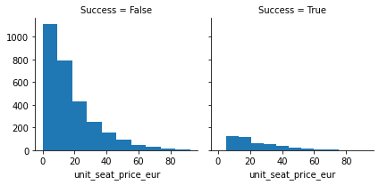

```python
g = sns.FacetGrid(df_viz, col='Success')
g.map(plt.hist, 'unit_seat_price_eur')
```

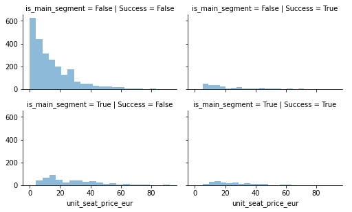

```python
grid = sns.FacetGrid(df_viz, col='Success', row='is_main_segment', size=2.2, aspect=1.6)
grid.map(plt.hist, 'unit_seat_price_eur', alpha=.5, bins=20)
grid.add_legend();
```

Next, we will check whether the dataset is imbalanced or balanced. If the dataset is imbalanced, we need to undersample majority or oversample minority to balance it.

# Balancing

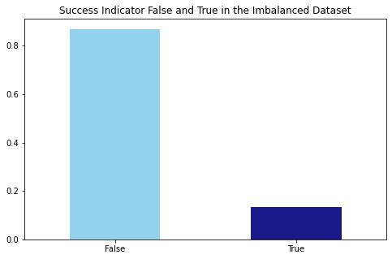

```python
import matplotlib.pyplot as plt
fig = plt.figure(figsize = (8,5))
df.Success.value_counts(normalize = True).plot(kind='bar', color= ['skyblue','navy'], alpha = 0.9, rot=0)
plt.title('Success Indicator False and True in the Imbalanced Dataset')
plt.show()
```

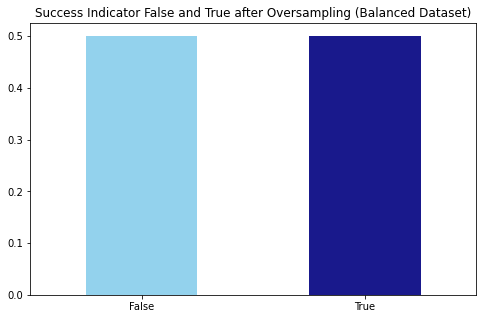

```python
from sklearn.utils import resample

no = df[df.Success == False]
yes = df[df.Success == True]
yes_oversampled = resample(yes, replace=True, n_samples=len(no), random_state=123)
oversampled = pd.concat([no, yes_oversampled])
oversampled_viz = oversampled.sample(frac=0.001)
fig = plt.figure(figsize = (8,5))
oversampled_viz.Success.value_counts(normalize = True).plot(kind='bar', color= ['skyblue','navy'], alpha = 0.9, rot=0)
plt.title('Success Indicator False and True after Oversampling (Balanced Dataset)')
plt.show()
```

```python
len(df)
```

```
3379778
```

```python
len(oversampled)
```

```
5867120
```

# Encoding

```python
# Convert categorical features to continuous features with Label Encoding
from sklearn.preprocessing import LabelEncoder
lencoders = {}
for col in oversampled.select_dtypes(include=['category']).columns:
    lencoders[col] = LabelEncoder()
    oversampled[col] = lencoders[col].fit_transform(oversampled[col])
```

The following pairs of features are having high correlation between them:

```python
oversampled_viz.columns
```

```
Index(['fixed_signup_country', 'is_main_segment', 'unit_seat_price_eur',
       'seat_offered_count', 'segment_distance_km', 'from_lat', 'from_lon',
       'to_lat', 'to_lon', 'is_comfort', 'is_auto_accept_mode',
       'publication_site_id', 'year_segment_datetime',
       'month_segment_datetime', 'day_segment_datetime',
       'dayofyear_segment_datetime', 'dayofweek_segment_datetime',
       'weekday_segment_datetime', 'weekday_name_segment_datetime',
       'quarter_segment_datetime', 'hour_segment_datetime',
       'minutes_segment_datetime', 'year_published_date',
       'month_published_date', 'day_published_date',
       'dayofyear_published_date', 'dayofweek_published_date',
       'weekday_published_date', 'weekday_name_published_date',
       'quarter_published_date', 'hour_published_date',
       'minutes_published_date', 'year_signup_date', 'month_signup_date',
       'day_signup_date', 'dayofyear_signup_date', 'dayofweek_signup_date',
       'weekday_signup_date', 'weekday_name_signup_date',
       'quarter_signup_date', 'hour_signup_date', 'minutes_signup_date',
       'Success'],
      dtype='object')
```

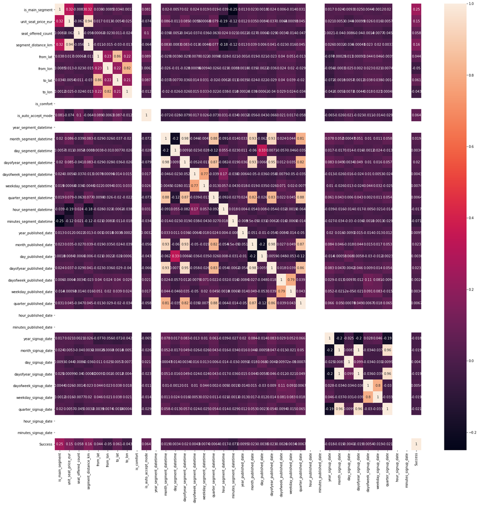

```python
import matplotlib.pyplot as plt
import seaborn as sn
fig, ax = plt.subplots(figsize=(25,25))         # Sample figsize in inches
sn.heatmap(df_viz.corr(), annot=True)
ax
```

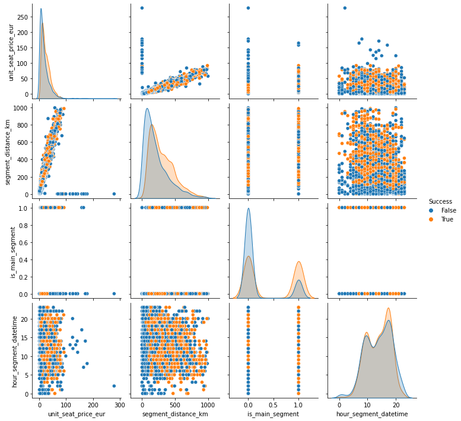

```python
sns.pairplot( data=oversampled_viz, vars=('unit_seat_price_eur','segment_distance_km','is_main_segment','hour_segment_datetime'), hue='Success' )
```

**Feature Selection**

- We will use both filter method and wrapper method for feature selection.
- (1) Feature Selection by Filter Method (Chi-Square Value): Before performing this, we need to standardize our data first. We are using MinMaxScaler instead of StandardScaler in order to avoid negative values.

```python
oversampled.info()
```

```
<class 'pandas.core.frame.DataFrame'>
Int64Index: 5867120 entries, 0 to 1146589
Data columns (total 43 columns):
 #   Column                         Dtype
---  ------                         -----
 0   fixed_signup_country           int64
 1   is_main_segment                bool
 2   unit_seat_price_eur            float64
 3   seat_offered_count             int64
 4   segment_distance_km            float64
 5   from_lat                       float64
 6   from_lon                       float64
 7   to_lat                         float64
 8   to_lon                         float64
 9   is_comfort                     bool
```

[output cut: 35 more lines]

```python
oversampled_s = oversampled.sample(frac=0.01)
oversampled_n = oversampled_s._get_numeric_data()
```

```python
oversampled_n.head()
```

|  | fixed_signup_country | is_main_segment | unit_seat_price_eur | seat_offered_count | segment_distance_km | from_lat | from_lon | to_lat | to_lon | is_comfort | is_auto_accept_mode | publication_site_id | year_segment_datetime | month_segment_datetime | day_segment_datetime | dayofyear_segment_datetime | dayofweek_segment_datetime | weekday_segment_datetime | weekday_name_segment_datetime | quarter_segment_datetime | hour_segment_datetime | minutes_segment_datetime | year_published_date | month_published_date | day_published_date | dayofyear_published_date | dayofweek_published_date | weekday_published_date | weekday_name_published_date | … |
| --- | --- | --- | --- | --- | --- | --- | --- | --- | --- | --- | --- | --- | --- | --- | --- | --- | --- | --- | --- | --- | --- | --- | --- | --- | --- | --- | --- | --- | --- | --- |
| 2134265 | 9 | True | 6.60 | 3 | 113.0 | 47.2158 | -1.557270 | 48.1152 | -1.683070 | False | True | 1 | 2015 | 8 | 14 | 226 | 4 | 0 | 0 | 3 | 17 | 50 | 2015 | 8 | 11 | 223 | 1 | 0 | 5 | … |
| 2763512 | 9 | True | 6.60 | 3 | 85.0 | 49.0478 | -1.445260 | 49.6337 | -1.622140 | False | True | 24 | 2015 | 6 | 17 | 168 | 2 | 0 | 6 | 2 | 11 | 0 | 2015 | 6 | 15 | 166 | 0 | 0 | 1 | … |
| 1304677 | 9 | False | 11.88 | 3 | 147.0 | 45.7640 | 4.835660 | 46.6712 | 5.550470 | False | False | 1 | 2015 | 7 | 14 | 195 | 1 | 0 | 5 | 3 | 22 | 0 | 2015 | 7 | 4 | 185 | 5 | 1 | 2 | … |
| 2416549 | 9 | False | 1.32 | 1 | 27.0 | 48.4604 | -0.197313 | 48.4329 | 0.091266 | False | False | 1 | 2015 | 5 | 10 | 130 | 6 | 1 | 3 | 2 | 18 | 30 | 2015 | 5 | 4 | 124 | 0 | 0 | 1 | … |
| 2888060 | 9 | False | 3.96 | 3 | 46.0 | 47.8268 | -0.706845 | 47.4784 | -0.563166 | False | False | 17 | 2015 | 7 | 5 | 186 | 6 | 1 | 3 | 3 | 14 | 0 | 2015 | 7 | 1 | 182 | 2 | 0 | 6 | … |

# Standardizing data

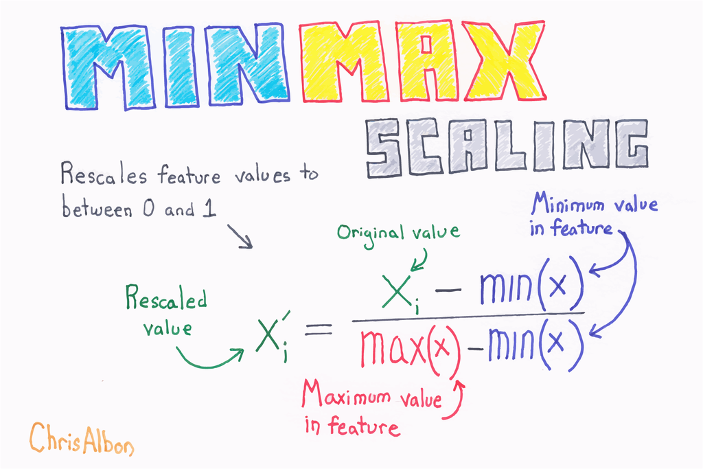

```python
from sklearn import preprocessing
r_scaler = preprocessing.MinMaxScaler()
r_scaler.fit(oversampled_n)
modified_data = pd.DataFrame(r_scaler.transform(oversampled_n), index=oversampled_s.index, columns=oversampled_n.columns)
modified_data.head()
```

[output not shown]

### Feature Importance

**Chi²**

A chi-square test is used in statistics to test the independence of two events. Given the data of two variables, we can get observed count O and expected count E. Chi-Square measures how expected count E and observed count O deviates each other.

```python
# Feature Importance using Filter Method (Chi-Square)
from sklearn.feature_selection import SelectKBest, chi2
X = modified_data.loc[:,modified_data.columns!='Success']
y = modified_data[['Success']]
selector = SelectKBest(chi2, k=10)
selector.fit(X, y)
X_new = selector.transform(X)
print(X.columns[selector.get_support(indices=True)])
```

```
Index(['is_main_segment', 'unit_seat_price_eur', 'seat_offered_count',
       'segment_distance_km', 'is_auto_accept_mode', 'publication_site_id',
       'dayofyear_segment_datetime', 'quarter_segment_datetime',
       'minutes_segment_datetime', 'year_signup_date'],
      dtype='object')
```

**Random forest**

Feature importance is calculated as the decrease in node impurity weighted by the probability of reaching that node. The node probability can be calculated by the number of samples that reach the node, divided by the total number of samples. The higher the value the more important the feature.

```python
from sklearn.feature_selection import SelectFromModel
from sklearn.ensemble import RandomForestClassifier as rf

X = modified_data.drop('Success', axis=1)
y = modified_data['Success']
selector = SelectFromModel(rf(n_estimators=100, random_state=0))
selector.fit(X, y)
support = selector.get_support()
features = X.loc[:,support].columns.tolist()
print(features)
print(rf(n_estimators=100, random_state=0).fit(X,y).feature_importances_)
```

```
['is_main_segment', 'unit_seat_price_eur', 'segment_distance_km', 'from_lat', 'from_lon', 'to_lat', 'to_lon', 'day_segment_datetime', 'dayofyear_segment_datetime', 'hour_segment_datetime', 'minutes_segment_datetime', 'day_published_date', 'dayofyear_published_date', 'day_signup_date', 'dayofyear_sig…
[3.30629316e-03 5.41375144e-02 9.81446188e-02 1.99254053e-02
 1.02084114e-01 5.73903568e-02 5.28255982e-02 5.52143114e-02
 5.10686711e-02 0.00000000e+00 1.10692452e-02 1.11288894e-02
 0.00000000e+00 9.91780469e-03 3.28163891e-02 3.44328334e-02
 1.77715469e-02 5.04389197e-03 1.83450756e-02 2.57221929e-03
 3.60935084e-02 2.66054768e-02 9.00370737e-06 9.82589276e-03
 3.33665907e-02 3.52080196e-02 1.85539022e-02 4.56335200e-03
 1.91005681e-02 2.84492461e-03 0.00000000e+00 0.00000000e+00
 2.20335043e-02 2.24934445e-02 3.67867501e-02 4.07763519e-02
 1.96234867e-02 4.76789462e-03 1.96732040e-02 1.04793463e-02
 0.00000000e+00 0.00000000e+00]
```

**Permutation Importance**

eli5 provides a way to compute feature importances for any black-box estimator by measuring how score decreases when a feature is not available; the method is also known as “permutation importance”

```python
pip install eli5
```

```python
import eli5
from eli5.sklearn import PermutationImportance

perm = PermutationImportance(rf(n_estimators=100, random_state=0).fit(X,y),random_state=1).fit(X,y)
eli5.show_weights(perm, feature_names = X.columns.tolist())
```

| Weight | Feature |
| --- | --- |
| 0.1152 ± 0.0014 | is_main_segment |
| 0.0586 ± 0.0010 | segment_distance_km |
| 0.0559 ± 0.0008 | is_auto_accept_mode |
| 0.0348 ± 0.0014 | unit_seat_price_eur |
| 0.0259 ± 0.0006 | from_lat |
| 0.0208 ± 0.0004 | to_lat |
| 0.0180 ± 0.0008 | minutes_segment_datetime |
| 0.0157 ± 0.0006 | from_lon |
| 0.0103 ± 0.0008 | to_lon |
| 0.0073 ± 0.0005 | seat_offered_count |
| 0.0056 ± 0.0003 | year_signup_date |
| 0.0045 ± 0.0002 | hour_segment_datetime |
| 0.0014 ± 0.0002 | dayofyear_signup_date |
| 0.0014 ± 0.0003 | day_signup_date |
| 0.0009 ± 0.0002 | dayofyear_published_date |
| 0.0007 ± 0.0002 | day_published_date |
| 0.0007 ± 0.0001 | day_segment_datetime |
| 0.0005 ± 0.0001 | dayofyear_segment_datetime |
| 0.0003 ± 0.0000 | weekday_name_published_date |
| 0.0002 ± 0.0001 | dayofweek_segment_datetime |
| *… 22 more …* |  |

# Build a prediction model for Success

**Split the dataset in train test set**

```python
X = modified_data.drop('Success', axis=1)
y = modified_data['Success']

# Split into test and train
from sklearn.model_selection import train_test_split
X_train, X_test, y_train, y_test = train_test_split(X, y, test_size=0.25, random_state=12345)

# Normalize Features
from sklearn.preprocessing import StandardScaler
scaler = StandardScaler()
X_train = scaler.fit_transform(X_train)
X_test = scaler.fit_transform(X_test)
```

**AUC** stands for Area Under the ROC Curve. ROC is a probability curve and AUC represents degree or measure of separability. It's used when we need to value how much model is capable of distinguishing between classes. The value is between 0 and 1, the higher the better.

An excellent model has **AUC** near to the 1 which means it has good measure of separability. A poor model has AUC near to the 0 which means it has worst measure of separability. When AUC score is 0.5, it means model has no class separation capacity whatsoever.

```python
def plot_roc_cur(fper, tper):
  """
  Function to plot the roc_curve
  """
  plt.plot(fper, tper, color='orange', label='ROC')
  plt.plot([0, 1], [0, 1], color='darkblue', linestyle='--')
  plt.xlabel('False Positive Rate')
  plt.ylabel('True Positive Rate')
  plt.title('Receiver Operating Characteristic (ROC) Curve')
  plt.legend()
  plt.show()
```

**Cohen's Kappa** can vary from -1 to +1 .

when k = 0, the chord is not better than what would be obtained by chance. when k is negative, the chord is less than what would be expected by chance. when k is positive, the evaluation agreement exceeds the random agreement.

**Confusion table** (or confusion matrix) shows how many True positives (TP), True Negative (TN), False Positive (FP) and False Negative (FN) model has made.

|  |  | Actual | Actual |
| --- | --- | --- | --- |
|  |  | Positive (1) | Negative (0) |
| Predicted | Positive (1) | TP | FP |
| Predicted | Negative (0) | FN | TN |

- True Positives (TP): When the actual class of the observation is 1 (True) and the prediction is 1 (True)
- True Negative (TN): When the actual class of the observation is 0 (False) and the prediction is 0 (False)
- False Positive (FP): When the actual class of the observation is 0 (False) and the prediction is 1 (True)
- False Negative (FN): When the actual class of the observation is 1 (True) and the prediction is 0 (False)

Most of the performance metrics for classification models are based on the values of the confusion matrix.

**Precision and recall**

- Precision and recall are classification evaluation metrics:
- P = TP / (TP + FP) and R = TP / (TP + FN).
- Where TP is true positives, FP is false positives and FN is false negatives
- In both cases the score of 1 is the best: we get no false positives or false negatives and only true positives.
- F1 is a combination of both precision and recall in one score (harmonic mean):
- F1 = 2 * PR / (P + R).
- Max F score is 1 and min is 0, with 1 being the best.

```python
import time
from sklearn.metrics import accuracy_score, roc_auc_score, cohen_kappa_score, plot_confusion_matrix, roc_curve, classification_report
def run_model(model, X_train, y_train, X_test, y_test, verbose=True):
    """
      return the model, metrics and time of executions
      Function to "industrialize" the training, scoring and prediction of a model.
    """

    t0_fit_pred=time.time()
    if verbose == False:
        model.fit(X_train,y_train, verbose=0)
    else:
        model.fit(X_train,y_train)
    time_taken_fit=time.time()-t0_fit_pred
    t0_pred= time.time()
    y_pred = model.predict(X_test)
    time_taken_pred=time.time()-t0_pred
    t0_ac = time.time()
    accuracy = accuracy_score(y_test, y_pred)
    time_taken_ac=time.time()-t0_ac
    roc_auc = roc_auc_score(y_test, y_pred)
    coh_kap = cohen_kappa_score(y_test, y_pred)
    time_taken_fit_pred = time.time()-t0_fit_pred
    print("Accuracy = {}".format(accuracy))
    print("ROC Area under Curve = {}".format(roc_auc))
    print("Cohen's Kappa = {}".format(coh_kap))
    print("Time taken for prediction = {}".format(time_taken_pred))
    print("Time taken for fit and predict = {}".format(time_taken_fit_pred))
    print(classification_report(y_test,y_pred,digits=5))

    probs = model.predict_proba(X_test)
    probs = probs[:, 1]
    fper, tper, thresholds = roc_curve(y_test, probs)
    plot_roc_cur(fper, tper)

    plot_confusion_matrix(model, X_test, y_test,cmap=plt.cm.Blues, normalize = 'all')

    return model, accuracy, roc_auc, coh_kap, time_taken_fit_pred,time_taken_pred,time_taken_ac
```

Logistic Regression is considered a generalized linear model because the outcome always depends on the sum of the inputs and parameters. Or in other words, the output cannot depend on the product (or quotient, etc.) of its parameters.

A sigmoid function is a type of activation function, and more specifically defined as a squashing function. Squashing functions limit the output to a range between 0 and 1, making these functions useful in the prediction of probabilities.

Sigmod(x) = 1/(1+e^{-x})

```
Accuracy = 0.6644395964003272
ROC Area under Curve = 0.6652934296916063
Cohen's Kappa = 0.3299921738266146
Time taken for prediction = 0.0054624080657958984
Time taken for fit and predict = 1.169152021408081
              precision    recall  f1-score   support

         0.0    0.63904   0.73727   0.68465      7247
         1.0    0.69811   0.59332   0.64146      7421

    accuracy                        0.66444     14668
   macro avg    0.66858   0.66529   0.66306     14668
weighted avg    0.66893   0.66444   0.66280     14668
```

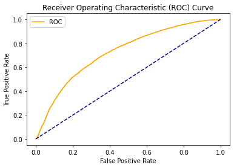

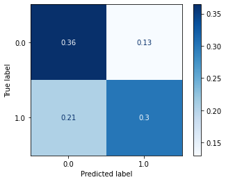

```python
from sklearn.linear_model import LogisticRegression

params_lr = {'penalty': 'l1', 'solver':'liblinear'}

model_lr = LogisticRegression(**params_lr)
model_lr, accuracy_lr, roc_auc_lr, coh_kap_lr, time_taken_fit_pred_lr,time_taken_pred_lr,time_taken_ac_lr = run_model(model_lr, X_train, y_train, X_test, y_test)
```

In **Decision tree** , we split the population into two or more homogeneous sets. This is done based on most significant attributes/ independent variables to make as distinct groups as possible.

A decision tree is a flowchart-like tree structure, where each internal node (non-leaf node) denotes a test on an attribute, each branch represents an outcome of the test, and each leaf node (or terminal node) holds a value for the target variable.

Various techniques : like Gini, Information Gain, Chi-square, entropy.

```
Accuracy = 0.646509408235615
ROC Area under Curve = 0.6459233896802541
Cohen's Kappa = 0.292160131770963
Time taken for prediction = 0.004609584808349609
Time taken for fit and predict = 0.18011832237243652
              precision    recall  f1-score   support

         0.0    0.65659   0.59652   0.62512      7247
         1.0    0.63830   0.69532   0.66559      7421

    accuracy                        0.64651     14668
   macro avg    0.64744   0.64592   0.64535     14668
weighted avg    0.64734   0.64651   0.64559     14668
```

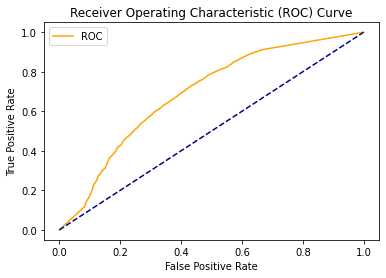

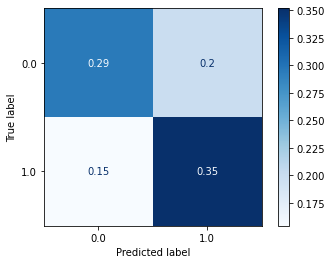

```python
from sklearn.tree import DecisionTreeClassifier

params_dt = {'max_depth': 16,
             'max_features': "sqrt"}

model_dt = DecisionTreeClassifier(**params_dt)
model_dt, accuracy_dt, roc_auc_dt, coh_kap_dt, time_taken_fit_pred_dt,time_taken_pred_dt,time_taken_ac_dt = run_model(model_dt, X_train, y_train, X_test, y_test)
```

```
Accuracy = 0.6677120261794383
ROC Area under Curve = 0.6671330359376993
Cohen's Kappa = 0.3346222598731513
Time taken for prediction = 0.0567474365234375
Time taken for fit and predict = 136.9087142944336
              precision    recall  f1-score   support

         0.0    0.68007   0.61832   0.64773      7247
         1.0    0.65763   0.71594   0.68555      7421

    accuracy                        0.66771     14668
   macro avg    0.66885   0.66713   0.66664     14668
weighted avg    0.66872   0.66771   0.66686     14668
```

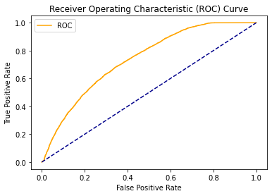

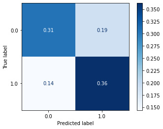

```python
from sklearn.neural_network import MLPClassifier

params_nn = {'hidden_layer_sizes': (30,30,30),
             'activation': 'logistic',
             'solver': 'lbfgs',
             'max_iter': 500}

model_nn = MLPClassifier(**params_nn)
model_nn, accuracy_nn, roc_auc_nn, coh_kap_nn, time_taken_fit_pred_nn,time_taken_pred_nn,time_taken_ac_nn = run_model(model_nn, X_train, y_train, X_test, y_test)
```

Random Forests builds each tree independently and then combine results at the end of the process (by averaging or "majority rules")

```
Accuracy = 0.7050040905372239
ROC Area under Curve = 0.7046252818915705
Cohen's Kappa = 0.4095268231213224
Time taken for prediction = 0.330812931060791
Time taken for fit and predict = 10.116803169250488
              precision    recall  f1-score   support

         0.0    0.71376   0.67269   0.69262      7247
         1.0    0.69737   0.73656   0.71643      7421

    accuracy                        0.70500     14668
   macro avg    0.70557   0.70463   0.70452     14668
weighted avg    0.70547   0.70500   0.70467     14668
```

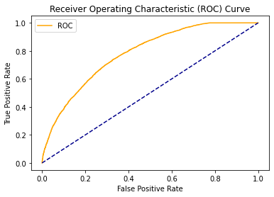

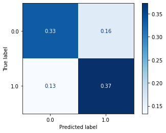

```python
from sklearn.ensemble import RandomForestClassifier

params_rf = {'max_depth': 16,
             'min_samples_leaf': 1,
             'min_samples_split': 2,
             'n_estimators': 100,
             'random_state': 12345}

model_rf = RandomForestClassifier(**params_rf)
model_rf, accuracy_rf, roc_auc_rf, coh_kap_rf, time_taken_fit_pred_rf,time_taken_pred_rf,time_taken_ac_rf = run_model(model_rf, X_train, y_train, X_test, y_test)
```

**CatBoost** is an open-source gradient boosting on decision trees library with categorical features support out of the box, Successor of the MatrixNet algorithm developed by Yandex.

```
Accuracy = 0.6712571584401418
ROC Area under Curve = 0.6709908836534304
Cohen's Kappa = 0.34213231064929794
Time taken for prediction = 0.024712800979614258
Time taken for fit and predict = 177.89182925224304
              precision    recall  f1-score   support

         0.0    0.67384   0.64854   0.66095      7247
         1.0    0.66892   0.69344   0.68096      7421

    accuracy                        0.67126     14668
   macro avg    0.67138   0.67099   0.67095     14668
weighted avg    0.67135   0.67126   0.67107     14668
```

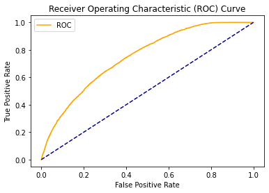

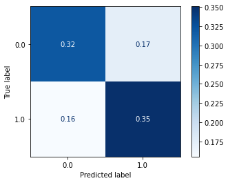

```python
import catboost as cb
params_cb ={'iterations': 50,
            'max_depth': 16}

model_cb = cb.CatBoostClassifier(**params_cb)
model_cb, accuracy_cb, roc_auc_cb, coh_kap_cb, time_taken_fit_pred_cb,time_taken_pred_cb,time_taken_ac_cb = run_model(model_cb, X_train, y_train, X_test, y_test, verbose=False)
```

**Gradient boosting** is a machine learning technique for regression and classification problems, which produces a prediction model in the form of an ensemble of weak prediction models, typically decision trees.

```
Accuracy = 0.7152304335969457
ROC Area under Curve = 0.7154791149354498
Cohen's Kappa = 0.4307094866730522
Time taken for prediction = 3.1023004055023193
Time taken for fit and predict = 177.04295253753662
              precision    recall  f1-score   support

         0.0    0.70187   0.73644   0.71874      7247
         1.0    0.72961   0.69452   0.71163      7421

    accuracy                        0.71523     14668
   macro avg    0.71574   0.71548   0.71519     14668
weighted avg    0.71591   0.71523   0.71514     14668
```

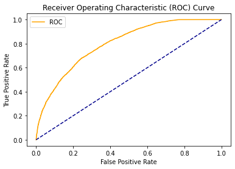

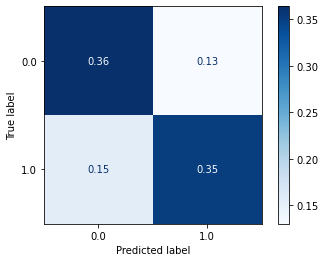

```python
import xgboost as xgb
params_xgb ={'n_estimators': 500,
            'max_depth': 16}

model_xgb = xgb.XGBClassifier(**params_xgb)
model_xgb, accuracy_xgb, roc_auc_xgb, coh_kap_xgb, time_taken_fit_pred_xgb,time_taken_pred_xgb,time_taken_ac_xgb = run_model(model_xgb, X_train, y_train, X_test, y_test)
```

**Light GBM** is a fast, distributed, high-performance gradient boosting framework based on decision tree algorithm, used for ranking, classification and many other machine learning tasks.

Since it is based on decision tree algorithms, it splits the tree leaf wise with the best fit whereas other boosting algorithms split the tree depth wise or level wise rather than leaf-wise. So when growing on the same leaf in Light GBM, the leaf-wise algorithm can reduce more loss than the level-wise algorithm and hence results in much better accuracy which can rarely be achieved by any of the existing boosting algorithms. Also, it is surprisingly very fast, hence the word ‘Light’.

```
Accuracy = 0.7195936733024271
ROC Area under Curve = 0.719728111871801
Cohen's Kappa = 0.43930343139197514
Time taken for prediction = 0.219940185546875
Time taken for fit and predict = 3.6497037410736084
              precision    recall  f1-score   support

         0.0    0.71000   0.73106   0.72038      7247
         1.0    0.72953   0.70840   0.71881      7421

    accuracy                        0.71959     14668
   macro avg    0.71976   0.71973   0.71959     14668
weighted avg    0.71988   0.71959   0.71958     14668
```

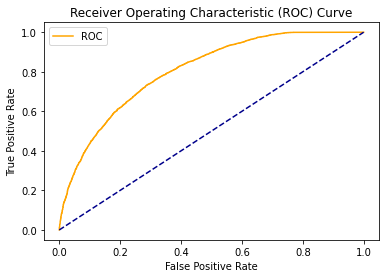

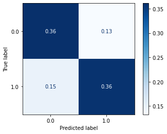

```python
import lightgbm as lgb
params_lgb ={'colsample_bytree': 0.95,
         'max_depth': 16,
         'min_split_gain': 0.1,
         'n_estimators': 200,
         'num_leaves': 50,
         'reg_alpha': 1.2,
         'reg_lambda': 1.2,
         'subsample': 0.95,
         'subsample_freq': 20}

model_lgb = lgb.LGBMClassifier(**params_lgb)
model_lgb, accuracy_lgb, roc_auc_lgb, coh_kap_lgb, time_taken_fit_pred_lgb,time_taken_pred_lgb,time_taken_ac_lgb = run_model(model_lgb, X_train, y_train, X_test, y_test)
```

# Comparison

As the model would be deployed in production and therefore it should reach best compromise between precision and speed of predictions.

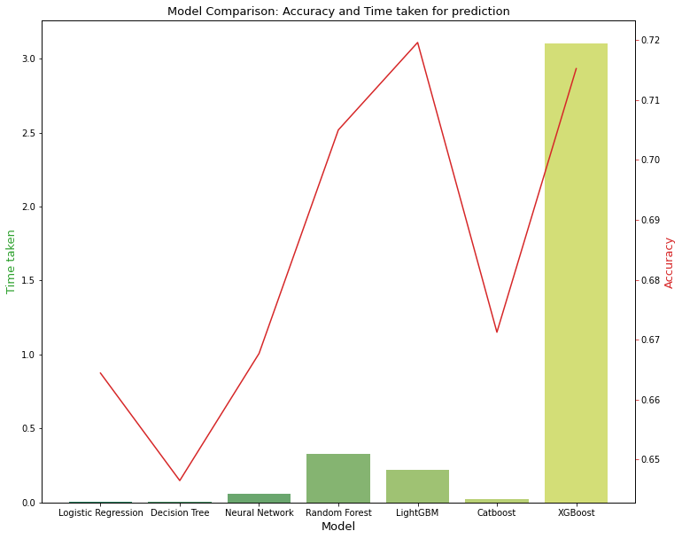

```python
accuracy_scores = [accuracy_lr, accuracy_dt, accuracy_nn, accuracy_rf, accuracy_lgb, accuracy_cb, accuracy_xgb]
roc_auc_scores = [roc_auc_lr, roc_auc_dt, roc_auc_nn, roc_auc_rf, roc_auc_lgb, roc_auc_cb, roc_auc_xgb]
coh_kap_scores = [coh_kap_lr, coh_kap_dt, coh_kap_nn, coh_kap_rf, coh_kap_lgb, coh_kap_cb, coh_kap_xgb]
tt = [time_taken_pred_lr, time_taken_pred_dt, time_taken_pred_nn, time_taken_pred_rf, time_taken_pred_lgb, time_taken_pred_cb, time_taken_pred_xgb]

model_data = {'Model': ['Logistic Regression','Decision Tree','Neural Network','Random Forest','LightGBM','Catboost','XGBoost'],
              'Accuracy': accuracy_scores,
              'ROC_AUC': roc_auc_scores,
              'Cohen_Kappa': coh_kap_scores,
              'Time taken': tt}
data = pd.DataFrame(model_data)

fig, ax1 = plt.subplots(figsize=(12,10))
ax1.set_title('Model Comparison: Accuracy and Time taken for prediction', fontsize=13)
color = 'tab:green'
ax1.set_xlabel('Model', fontsize=13)
ax1.set_ylabel('Time taken', fontsize=13, color=color)
ax2 = sns.barplot(x='Model', y='Time taken', data = data, palette='summer')
ax1.tick_params(axis='y')
ax2 = ax1.twinx()
color = 'tab:red'
ax2.set_ylabel('Accuracy', fontsize=13, color=color)
ax2 = sns.lineplot(x='Model', y='Accuracy', data = data, sort=False, color=color)
ax2.tick_params(axis='y', color=color)
```

It looks like the best model is LightGBM, according to the accuracy and the time taken for prediction

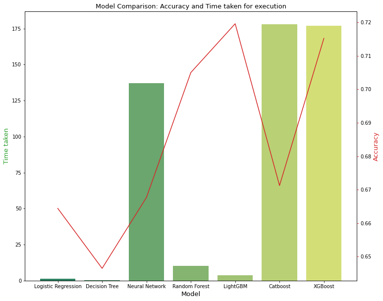

```python
accuracy_scores = [accuracy_lr, accuracy_dt, accuracy_nn, accuracy_rf, accuracy_lgb, accuracy_cb, accuracy_xgb]
roc_auc_scores = [roc_auc_lr, roc_auc_dt, roc_auc_nn, roc_auc_rf, roc_auc_lgb, roc_auc_cb, roc_auc_xgb]
coh_kap_scores = [coh_kap_lr, coh_kap_dt, coh_kap_nn, coh_kap_rf, coh_kap_lgb, coh_kap_cb, coh_kap_xgb]
tt = [time_taken_fit_pred_lr, time_taken_fit_pred_dt, time_taken_fit_pred_nn, time_taken_fit_pred_rf, time_taken_fit_pred_lgb, time_taken_fit_pred_cb, time_taken_fit_pred_xgb]

model_data = {'Model': ['Logistic Regression','Decision Tree','Neural Network','Random Forest','LightGBM','Catboost','XGBoost'],
              'Accuracy': accuracy_scores,
              'ROC_AUC': roc_auc_scores,
              'Cohen_Kappa': coh_kap_scores,
              'Time taken': tt}
data = pd.DataFrame(model_data)

fig, ax1 = plt.subplots(figsize=(12,10))
ax1.set_title('Model Comparison: Accuracy and Time taken for execution', fontsize=13)
color = 'tab:green'
ax1.set_xlabel('Model', fontsize=13)
ax1.set_ylabel('Time taken', fontsize=13, color=color)
ax2 = sns.barplot(x='Model', y='Time taken', data = data, palette='summer')
ax1.tick_params(axis='y')
ax2 = ax1.twinx()
color = 'tab:red'
ax2.set_ylabel('Accuracy', fontsize=13, color=color)
ax2 = sns.lineplot(x='Model', y='Accuracy', data = data, sort=False, color=color)
ax2.tick_params(axis='y', color=color)
```

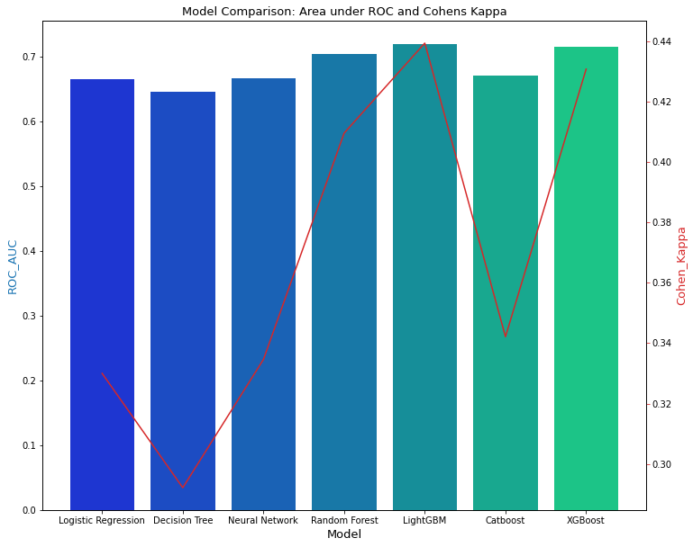

```python
fig, ax3 = plt.subplots(figsize=(12,10))
ax3.set_title('Model Comparison: Area under ROC and Cohens Kappa', fontsize=13)
color = 'tab:blue'
ax3.set_xlabel('Model', fontsize=13)
ax3.set_ylabel('ROC_AUC', fontsize=13, color=color)
ax4 = sns.barplot(x='Model', y='ROC_AUC', data = data, palette='winter')
ax3.tick_params(axis='y')
ax4 = ax3.twinx()
color = 'tab:red'
ax4.set_ylabel('Cohen_Kappa', fontsize=13, color=color)
ax4 = sns.lineplot(x='Model', y='Cohen_Kappa', data = data, sort=False, color=color)
ax4.tick_params(axis='y', color=color)
plt.show()
```

Still, the best model is LightGBM, according to the Roc_AUC and the Cohen's Kappa

LightGBM is the best model with the best compromise between precision and speed of predictions.

# Feature importance

according to lightGBM

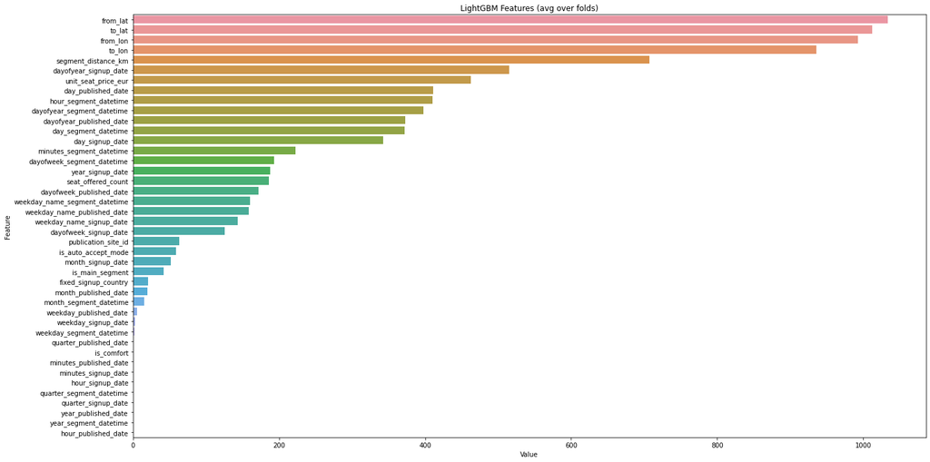

```python
import matplotlib.pyplot as plt
import seaborn as sns
import warnings
warnings.simplefilter(action='ignore', category=FutureWarning)

# sorted(zip(clf.feature_importances_, X.columns), reverse=True)
feature_imp = pd.DataFrame(sorted(zip(model_lgb.feature_importances_,X.columns)), columns=['Value','Feature'])

plt.figure(figsize=(20, 10))
sns.barplot(x="Value", y="Feature", data=feature_imp.sort_values(by="Value", ascending=False))
plt.title('LightGBM Features (avg over folds)')
plt.tight_layout()
plt.show()
plt.savefig('lgbm_importances-01.png')
```

We can see that geological features are really important. So, let's try to make a new features combining the 4 best features in this model: from_lat, to_lat, from_long, and to_long

**Geohash**

Geohash is a geocoding system for geographic coordinates (latitude / longitude) invented by Gustavo Niemeyer. The system is based on a hash function that subdivides the earth's surface according to a hierarchical grid.

```python
pip install pygeohash
```

```python
import pygeohash as gh
modified_data['from_geohash_4']=modified_data.apply(lambda x: gh.encode(x.from_lat, x.from_lon, precision=4), axis=1)
modified_data['from_geohash_5']=modified_data.apply(lambda x: gh.encode(x.from_lat, x.from_lon, precision=5), axis=1)
modified_data['from_geohash_6']=modified_data.apply(lambda x: gh.encode(x.from_lat, x.from_lon, precision=6), axis=1)

modified_data['to_geohash_4']=modified_data.apply(lambda x: gh.encode(x.to_lat, x.to_lon, precision=4), axis=1)
modified_data['to_geohash_5']=modified_data.apply(lambda x: gh.encode(x.to_lat, x.to_lon, precision=5), axis=1)
modified_data['to_geohash_6']=modified_data.apply(lambda x: gh.encode(x.to_lat, x.to_lon, precision=6), axis=1)
```

```python
modified_data.head()
```

[output not shown]

```python
from sklearn.preprocessing import LabelEncoder
lencoders = {}
for col in modified_data.select_dtypes(include=['object']).columns:
    lencoders[col] = LabelEncoder()
    modified_data[col] = lencoders[col].fit_transform(modified_data[col])
```

**Geohash importance**

Let's see if it is a good idea to create geohash features

```python
from sklearn.feature_selection import SelectFromModel
from sklearn.ensemble import RandomForestClassifier as rf

X = modified_data.drop('Success', axis=1)
y = modified_data['Success']
selector = SelectFromModel(rf(n_estimators=100, random_state=0))
selector.fit(X, y)
support = selector.get_support()
features = X.loc[:,support].columns.tolist()
print(features)
print(rf(n_estimators=100, random_state=0).fit(X,y).feature_importances_)
```

```
['is_main_segment', 'unit_seat_price_eur', 'segment_distance_km', 'from_lat', 'from_lon', 'to_lat', 'to_lon', 'day_segment_datetime', 'dayofyear_segment_datetime', 'hour_segment_datetime', 'minutes_segment_datetime', 'day_published_date', 'dayofyear_published_date', 'day_signup_date', 'dayofyear_sig…
[5.65886717e-02 9.14143657e-02 1.87704479e-02 9.71269149e-02
 4.86546214e-02 4.51386120e-02 4.61703564e-02 4.61942208e-02
 0.00000000e+00 1.03551211e-02 0.00000000e+00 1.07638649e-02
 3.22465947e-02 3.37549440e-02 1.92790766e-02 5.22162936e-03
 3.04418322e-03 3.37108063e-02 2.46304412e-02 2.22685128e-05
 1.04540209e-02 3.27696291e-02 3.44021064e-02 2.03188873e-02
 4.78296584e-03 3.61457589e-03 0.00000000e+00 0.00000000e+00
 2.10951808e-02 2.08293049e-02 3.43157855e-02 3.90603983e-02
 2.05107486e-02 5.10383360e-03 9.89502109e-03 0.00000000e+00
 0.00000000e+00 2.33504254e-03 1.90048440e-02 3.65188677e-02
 3.35691049e-03 2.13108647e-02 3.72338718e-02]
```

```python
X = modified_data.drop('Success', axis=1)
y = modified_data['Success']

# Split into test and train
from sklearn.model_selection import train_test_split
X_train, X_test, y_train, y_test = train_test_split(X, y, test_size=0.25, random_state=12345)

# Normalize Features
from sklearn.preprocessing import StandardScaler
scaler = StandardScaler()
X_train = scaler.fit_transform(X_train)
X_test = scaler.fit_transform(X_test)
```

```
Accuracy = 0.7262748841014454
ROC Area under Curve = 0.7262604639912649
Cohen's Kappa = 0.4525334218322815
Time taken for prediction = 0.13969206809997559
Time taken for fit and predict = 3.274179697036743
              precision    recall  f1-score   support

         0.0    0.72259   0.73587   0.72917      7345
         1.0    0.73011   0.71665   0.72331      7323

    accuracy                        0.72627     14668
   macro avg    0.72635   0.72626   0.72624     14668
weighted avg    0.72634   0.72627   0.72625     14668
```

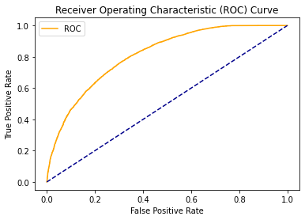

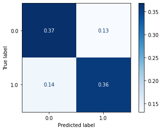

```python
import lightgbm as lgb
params_lgb ={'colsample_bytree': 0.95,
         'max_depth': 16,
         'min_split_gain': 0.1,
         'n_estimators': 200,
         'num_leaves': 50,
         'reg_alpha': 1.2,
         'reg_lambda': 1.2,
         'subsample': 0.95,
         'subsample_freq': 20}

model_lgb = lgb.LGBMClassifier(**params_lgb)
model_lgb, accuracy_lgb, roc_auc_lgb, coh_kap_lgb, time_taken_fit_pred_lgb,time_taken_pred_lgb,time_taken_ac_lgb = run_model(model_lgb, X_train, y_train, X_test, y_test)
```

[figure not shown]

```python
import matplotlib.pyplot as plt
import seaborn as sns
import warnings
warnings.simplefilter(action='ignore', category=FutureWarning)

# sorted(zip(clf.feature_importances_, X.columns), reverse=True)
feature_imp = pd.DataFrame(sorted(zip(model_lgb.feature_importances_,X.columns)), columns=['Value','Feature'])

plt.figure(figsize=(20, 10))
sns.barplot(x="Value", y="Feature", data=feature_imp.sort_values(by="Value", ascending=False))
plt.title('LightGBM Features (avg over folds)')
plt.tight_layout()
plt.show()
```

**Is it a good idea ?**

Yes it is it, according to all the metrics!

Thanks for reading, I enjoyed doing this project!